# Taller 3: ANOVA de un Factor

Bioestadistica Fundamental

Andres Felipe Florez Rivera

2026-07-27

Universidad Nacional de Colombia — Departamento de Estadistica, Sede Bogota

Este taller tiene dos partes. La **Parte I** presenta las herramientas en R necesarias para realizar un analisis completo de ANOVA de un factor. La **Parte II** plantea el trabajo que los estudiantes deben entregar, aplicando todas las herramientas aprendidas a un nuevo conjunto de datos.

# Parte I: Herramientas en R para ANOVA de un Factor

Para ilustrar cada herramienta se usa un conjunto de datos simulado con contexto agronomico: rendimiento del cultivo de maiz (t/ha) bajo cuatro tipos de fertilizante aplicados en 40 parcelas experimentales (10 parcelas por tipo). Los datos se generan de forma reproducible con `set.seed(2024)`.

```r
set.seed(2024)
n_por_grupo  <- 10
fertilizante <- factor(rep(c("Organico", "Quimico", "Mixto", "Control"), each = n_por_grupo))

medias_reales <- c(Organico = 5.6, Quimico = 6.4, Mixto = 6.9, Control = 4.8)
rendimiento <- round(
  medias_reales[as.character(fertilizante)] + rnorm(length(fertilizante), 0, 0.6),
  2
)

datos <- data.frame(fertilizante, rendimiento)

mostrar_tabla(datos, caption = "Rendimiento (t/ha) de maiz segun tipo de fertilizante")
```

Rendimiento (t/ha) de maiz segun tipo de fertilizante

[output not shown]

Las variables son:

| Variable | Descripcion | Tipo |
| --- | --- | --- |
| `fertilizante` | Tipo de fertilizante aplicado (Organico, Quimico, Mixto, Control) | Cualitativa (factor con 4 niveles) |
| `rendimiento` | Rendimiento del cultivo de maiz | Cuantitativa (t/ha) |

## 1. Exploracion inicial de los datos

Antes de ajustar un modelo ANOVA siempre se deben explorar los datos por grupo.

### 1.1 Estadisticas descriptivas por grupo

```r
resumen_grupos <- aggregate(
  rendimiento ~ fertilizante,
  data = datos,
  FUN  = function(x) c(n = length(x), media = mean(x), sd = sd(x))
)
resumen_grupos <- do.call(data.frame, resumen_grupos)
names(resumen_grupos) <- c("fertilizante", "n", "media", "sd")
mostrar_tabla(round_df <- transform(resumen_grupos,
                                     media = round(media, 3),
                                     sd    = round(sd, 3)),
              caption = "Estadisticas descriptivas por tipo de fertilizante")
```

Estadisticas descriptivas por tipo de fertilizante

| fertilizante | n | media | sd |
| --- | --- | --- | --- |
| Control | 10 | 4.712 | 0.442 |
| Mixto | 10 | 6.872 | 0.625 |
| Organico | 10 | 5.699 | 0.530 |
| Quimico | 10 | 5.945 | 0.811 |

### 1.2 Diagrama de cajas por grupo

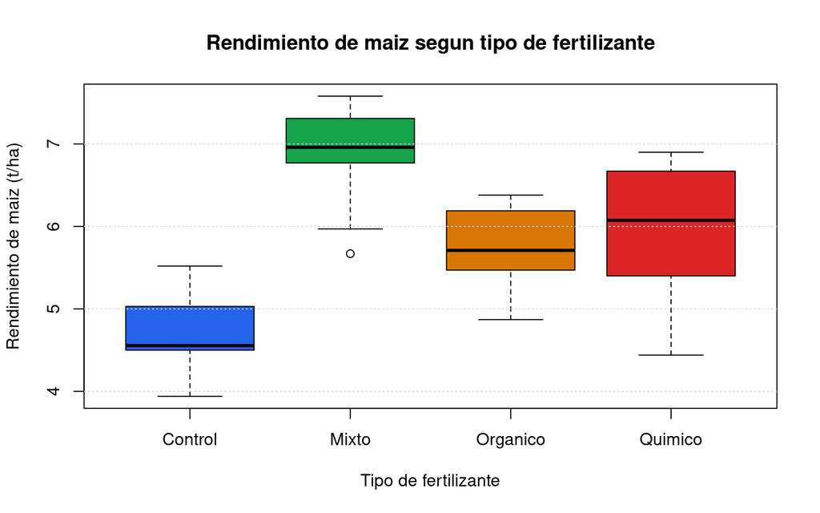

```r
boxplot(
  rendimiento ~ fertilizante,
  data = datos,
  col  = c("#2563eb", "#16a34a", "#d97706", "#dc2626"),
  xlab = "Tipo de fertilizante",
  ylab = "Rendimiento de maiz (t/ha)",
  main = "Rendimiento de maiz segun tipo de fertilizante"
)
grid(nx = NA, ny = NULL)
```

> Se observan diferencias visibles en la mediana y la dispersion del rendimiento entre los cuatro tipos de fertilizante, lo que sugiere que el factor podria tener un efecto significativo.

## 2. El modelo ANOVA de un factor

El modelo poblacional para un diseno de un factor con $k$ niveles es:

$$Y_{ij} = \mu + \tau_i + e_{ij}, \quad e_{ij} \sim N(0, \sigma^2), \quad i = 1,\ldots,k, \quad j = 1,\ldots,n_i$$

| Componente | Significado |
| --- | --- |
| $Y_{ij}$ | Observacion $j$ del tratamiento (nivel) $i$ |
| $\mu$ | Media general de la poblacion |
| $\tau_i$ | Efecto del tratamiento $i$ ($\tau_i = \mu_i - \mu$) |
| $e_{ij}$ | Error aleatorio asociado a la observacion $ij$ |

La hipotesis de interes es:

$$H_0: \mu_1 = \mu_2 = \cdots = \mu_k \quad \text{vs} \quad H_1: \text{al menos una } \mu_i \text{ es diferente}$$

Equivalentemente, en terminos de los efectos: $H_0: \tau_1 = \tau_2 = \cdots = \tau_k = 0$.

## 3. Descomposicion de la variabilidad

La variabilidad total de las observaciones se descompone en la variabilidad **entre** tratamientos y la variabilidad **dentro** de los tratamientos:

| Cantidad | Formula | Significado |
| --- | --- | --- |
| $SCTr$ | $\sum_i n_i (\bar{y}_i - \bar{y})^2$ | Variabilidad explicada por el factor (entre grupos) |
| $SCE$ | $\sum_i \sum_j (y_{ij} - \bar{y}_i)^2$ | Variabilidad no explicada (dentro de los grupos) |
| $SCT$ | $\sum_i \sum_j (y_{ij} - \bar{y})^2$ | Variabilidad total |

### 3.1 Calculo manual paso a paso

```r
ybar   <- mean(datos$rendimiento)
medias_i <- tapply(datos$rendimiento, datos$fertilizante, mean)
n_i      <- tapply(datos$rendimiento, datos$fertilizante, length)
k        <- length(medias_i)
N        <- nrow(datos)

SCTr <- sum(n_i * (medias_i - ybar)^2)
SCE  <- sum((datos$rendimiento - medias_i[as.character(datos$fertilizante)])^2)
SCT  <- sum((datos$rendimiento - ybar)^2)

cat("Media general       =", round(ybar, 4), "\n")
```

```
## Media general       = 5.807
```

```r
cat("SCTr (entre grupos) =", round(SCTr, 4), "\n")
```

```
## SCTr (entre grupos) = 23.6396
```

```r
cat("SCE  (dentro grupos)=", round(SCE, 4), "\n")
```

```
## SCE  (dentro grupos)= 13.7151
```

```r
cat("SCT  (total)        =", round(SCT, 4), "\n")
```

```
## SCT  (total)        = 37.3546
```

```r
cat("SCTr + SCE =", round(SCTr + SCE, 4), " (debe coincidir con SCT)\n")
```

```
## SCTr + SCE = 37.3546  (debe coincidir con SCT)
```

### 3.2 Tabla ANOVA manual

```r
gl_tr <- k - 1
gl_e  <- N - k
gl_t  <- N - 1

CMTr <- SCTr / gl_tr
CME  <- SCE  / gl_e
F_obs <- CMTr / CME
p_valor <- pf(F_obs, gl_tr, gl_e, lower.tail = FALSE)

tabla_anova <- data.frame(
  Fuente       = c("Fertilizante (entre)", "Error (dentro)", "Total"),
  GL           = c(gl_tr, gl_e, gl_t),
  SC           = round(c(SCTr, SCE, SCT), 4),
  CM           = c(round(CMTr, 4), round(CME, 4), NA),
  F_valor      = c(round(F_obs, 4), NA, NA),
  p_valor      = c(round(p_valor, 6), NA, NA)
)
mostrar_tabla(tabla_anova, caption = "Tabla ANOVA calculada manualmente")
```

Tabla ANOVA calculada manualmente

| Fuente | GL | SC | CM | F_valor | p_valor |
| --- | --- | --- | --- | --- | --- |
| Fertilizante (entre) | 3 | 23.6396 | 7.8799 | 20.6835 | 0 |
| Error (dentro) | 36 | 13.7151 | 0.3810 | NA | NA |
| Total | 39 | 37.3546 | NA | NA | NA |

## 4. Ajuste con `aov()` y verificacion

```r
modelo <- aov(rendimiento ~ fertilizante, data = datos)
summary(modelo)
```

```
##              Df Sum Sq Mean Sq F value  Pr(>F)
## fertilizante  3  23.64   7.880   20.68 5.8e-08 ***
## Residuals    36  13.71   0.381
## ---
## Signif. codes:  0 '***' 0.001 '**' 0.01 '*' 0.05 '.' 0.1 ' ' 1
```

> Los valores de $SC$, $GL$, $CM$, $F$ y el valor $p$ coinciden con el calculo manual: `aov()` implementa la misma descomposicion de varianza.

### 4.1 Ruta alternativa: `lm()` + `anova()`

```r
modelo_lm <- lm(rendimiento ~ fertilizante, data = datos)
anova(modelo_lm)
```

```
## Analysis of Variance Table
##
## Response: rendimiento
##              Df Sum Sq Mean Sq F value    Pr(>F)
## fertilizante  3 23.640  7.8799  20.683 5.801e-08 ***
## Residuals    36 13.715  0.3810
## ---
## Signif. codes:  0 '***' 0.001 '**' 0.01 '*' 0.05 '.' 0.1 ' ' 1
```

> `aov()` y `lm()` ajustan el mismo modelo lineal; `anova()` sobre el objeto `lm` reproduce la tabla ANOVA.

### 4.2 Decision estadistica

```r
cat("Estadistico F =", round(F_obs, 4), "\n")
```

```
## Estadistico F = 20.6835
```

```r
cat("Valor p       =", format.pval(p_valor, digits = 4), "\n")
```

```
## Valor p       = 5.801e-08
```

```r
cat(ifelse(p_valor < 0.05,
    "Se rechaza H0: al menos un tipo de fertilizante difiere en el rendimiento medio.",
    "No se rechaza H0: no hay evidencia de diferencias entre los rendimientos medios."), "\n")
```

```
## Se rechaza H0: al menos un tipo de fertilizante difiere en el rendimiento medio.
```

## 5. Medida de efecto: $R^2$ del ANOVA

Al igual que en regresion, la proporcion de variabilidad explicada por el factor se mide con:

$$R^2 = \frac{SCTr}{SCT}$$

```r
R2_manual <- SCTr / SCT
R2_lm     <- summary(modelo_lm)$r.squared

cat("R^2 (manual) =", round(R2_manual, 4), "\n")
```

```
## R^2 (manual) = 0.6328
```

```r
cat("R^2 (lm)     =", round(R2_lm,     4), "\n")
```

```
## R^2 (lm)     = 0.6328
```

```r
cat("\nEl tipo de fertilizante explica el", round(R2_lm * 100, 2),
    "% de la variabilidad del rendimiento.\n")
```

```
##
## El tipo de fertilizante explica el 63.28 % de la variabilidad del rendimiento.
```

## 6. Diagnostico de supuestos

Para que el ANOVA sea valido, el modelo debe satisfacer:

| Supuesto | Descripcion | Herramienta grafica | Prueba estadistica |
| --- | --- | --- | --- |
| Normalidad | $e_{ij} \sim N(0, \sigma^2)$ | Q-Q plot de residuos | Shapiro-Wilk |
| Homogeneidad de varianzas | $\sigma_1^2 = \sigma_2^2 = \cdots = \sigma_k^2$ | Boxplot / residuos vs ajustados | Bartlett |
| Independencia | Las observaciones son independientes entre si | — | Diseno experimental |

### 6.1 Graficos de diagnostico

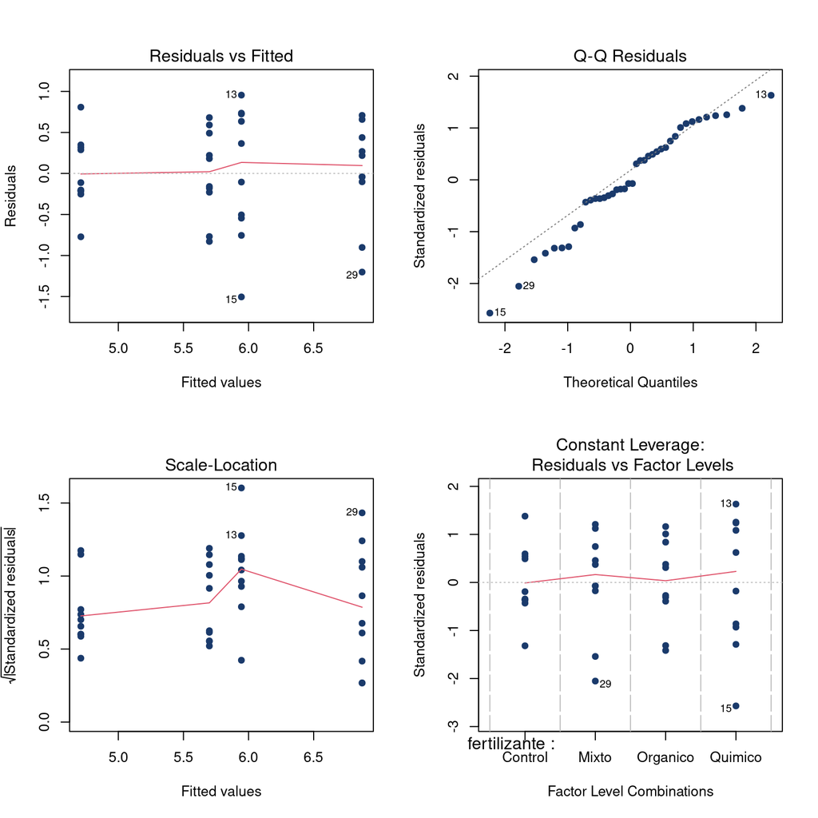

```r
par(mfrow = c(2, 2))
plot(modelo, col = "#1a3a6b", pch = 19, cex = 0.9)
```

```r
par(mfrow = c(1, 1))
```

### 6.2 Prueba de Shapiro-Wilk (normalidad)

$$H_0: \text{los residuos provienen de una distribucion normal} \quad \text{vs} \quad H_1: \text{no provienen de una distribucion normal}$$

```r
sw <- shapiro.test(residuals(modelo))
cat("Estadistico W =", round(sw$statistic, 4), "\n")
```

```
## Estadistico W = 0.959
```

```r
cat("Valor p       =", round(sw$p.value,   4), "\n")
```

```
## Valor p       = 0.1542
```

```r
cat(ifelse(sw$p.value > 0.05,
    "No se rechaza H0: los residuos son compatibles con normalidad.",
    "Se rechaza H0: los residuos no siguen una distribucion normal."), "\n")
```

```
## No se rechaza H0: los residuos son compatibles con normalidad.
```

> **Interpretacion:** el valor $p > 0.05$, por lo tanto **no se rechaza $H_0$**. Los residuos siguen una distribucion aproximadamente normal. El supuesto de normalidad **se cumple**.

### 6.3 Prueba de Bartlett (homogeneidad de varianzas)

$$H_0: \sigma_1^2 = \sigma_2^2 = \cdots = \sigma_k^2 \quad \text{vs} \quad H_1: \text{al menos una varianza es diferente}$$

```r
bt <- bartlett.test(rendimiento ~ fertilizante, data = datos)
print(bt)
```

```
##
##  Bartlett test of homogeneity of variances
##
## data:  rendimiento by fertilizante
## Bartlett's K-squared = 3.4604, df = 3, p-value = 0.3259
```

```r
cat(ifelse(bt$p.value > 0.05,
    "No se rechaza H0: las varianzas son homogeneas.",
    "Se rechaza H0: hay evidencia de heterogeneidad de varianzas."), "\n")
```

```
## No se rechaza H0: las varianzas son homogeneas.
```

> **Interpretacion:** el valor $p > 0.05$, por lo tanto **no se rechaza $H_0$**. Las varianzas de los cuatro grupos son homogeneas. El supuesto de homogeneidad **se cumple**.

### 6.4 Independencia

La independencia de las observaciones se garantiza por el **diseno del experimento** (asignacion aleatoria de parcelas a tratamientos) y no por una prueba posterior a los datos. Si el experimento se realizo con aleatorizacion adecuada y sin medidas repetidas sobre la misma unidad experimental, el supuesto se considera valido.

## 7. Comparaciones multiples: prueba de Tukey (HSD)

Cuando el ANOVA rechaza $H_0$, es necesario identificar **cuales** medias difieren entre si. La prueba de Tukey (HSD, *Honestly Significant Difference*) compara todos los pares de medias controlando el error tipo I global.

```r
tukey <- TukeyHSD(modelo)
print(tukey)
```

```
##   Tukey multiple comparisons of means
##     95% family-wise confidence level
##
## Fit: aov(formula = rendimiento ~ fertilizante, data = datos)
##
## $fertilizante
##                    diff        lwr        upr     p adj
## Mixto-Control     2.160  1.4165777  2.9034223 0.0000000
## Organico-Control  0.987  0.2435777  1.7304223 0.0053814
## Quimico-Control   1.233  0.4895777  1.9764223 0.0004233
## Organico-Mixto   -1.173 -1.9164223 -0.4295777 0.0008013
## Quimico-Mixto    -0.927 -1.6704223 -0.1835777 0.0096365
## Quimico-Organico  0.246 -0.4974223  0.9894223 0.8094232
```

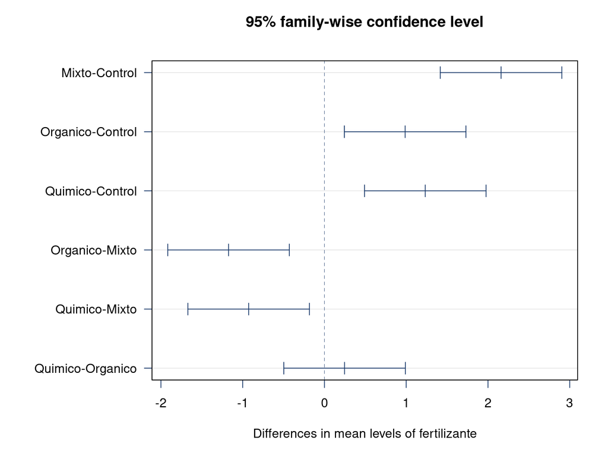

```r
par(mar = c(5, 10, 4, 2))
plot(tukey, las = 1, col = "#1a3a6b")
```

> Un intervalo de confianza que **no contiene el cero** indica una diferencia estadisticamente significativa entre ese par de tratamientos.

## 8. Visualizacion final: medias con intervalos de confianza

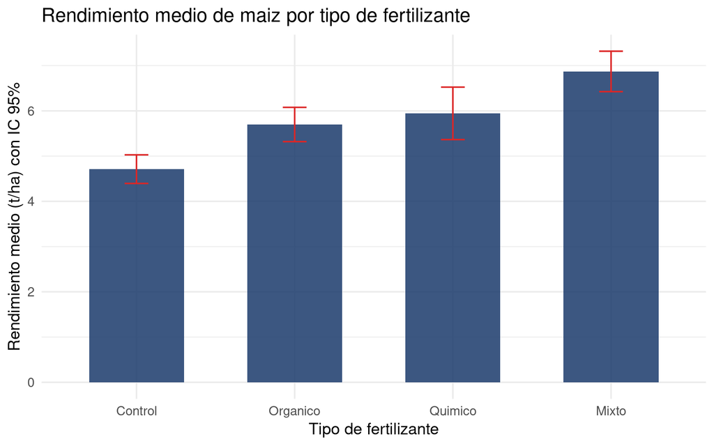

```r
library(ggplot2)

resumen <- data.frame(
  fertilizante = names(medias_i),
  media        = as.numeric(medias_i),
  n            = as.numeric(n_i)
)
resumen$sd  <- as.numeric(tapply(datos$rendimiento, datos$fertilizante, sd))
resumen$se  <- resumen$sd / sqrt(resumen$n)
resumen$ic  <- qt(0.975, resumen$n - 1) * resumen$se

ggplot(resumen, aes(x = reorder(fertilizante, media), y = media)) +
  geom_col(fill = "#1a3a6b", alpha = 0.85, width = 0.6) +
  geom_errorbar(aes(ymin = media - ic, ymax = media + ic), width = 0.15, color = "#dc2626") +
  labs(
    title = "Rendimiento medio de maiz por tipo de fertilizante",
    x     = "Tipo de fertilizante",
    y     = "Rendimiento medio (t/ha) con IC 95%"
  ) +
  theme_minimal(base_size = 13)
```

## 9. Resumen del flujo de trabajo en R

```r
#--- 1. Generar / cargar los datos ---
set.seed(2024)
datos <- data.frame(fertilizante, rendimiento)

#--- 2. Exploracion ---
aggregate(rendimiento ~ fertilizante, data = datos, FUN = mean)
boxplot(rendimiento ~ fertilizante, data = datos)

#--- 3. Ajuste del modelo ---
modelo <- aov(rendimiento ~ fertilizante, data = datos)
summary(modelo)

#--- 4. Diagnostico de supuestos ---
par(mfrow = c(2, 2))
plot(modelo)

shapiro.test(residuals(modelo))                      # Normalidad
bartlett.test(rendimiento ~ fertilizante, data = datos) # Homogeneidad de varianzas

#--- 5. Comparaciones multiples ---
TukeyHSD(modelo)
plot(TukeyHSD(modelo))
```

# Parte II: Trabajo para Entregar

## Instrucciones generales

El trabajo debe presentarse en formato de **articulo cientifico** con las siguientes secciones obligatorias: portada, introduccion, metodologia, desarrollo, conclusiones y bibliografia. Puede elaborarse en **Word, Google Docs, R Markdown o cualquier procesador de texto** de su preferencia, y debe entregarse en formato **PDF**.

El enfoque del trabajo es el **analisis e interpretacion de resultados**: cada salida de R debe ir acompanada de su correspondiente interpretacion en el contexto del problema. No basta con pegar el output; se debe explicar que significa.

**Fecha de entrega:** segun lo indicado por el docente. **Trabajo individual.**

## Contexto del problema

Un grupo de investigadores del sector agropecuario quiere determinar si la **variedad de cafe sembrada** (variable factor $X$, con cuatro niveles) tiene un efecto significativo sobre la **produccion de cafe pergamino seco** (variable $Y$, en kg/parcela) en fincas cafeteras del Eje Cafetero. Para ello se registraron datos de 48 parcelas experimentales (12 por variedad), asignadas de forma aleatoria.

Los datos se encuentran en el archivo **`datos_cafe_anova.csv`**, generado con el siguiente codigo, que debe ejecutarse **una sola vez** para crear el archivo en su directorio de trabajo. Luego puede cargarlo normalmente con `read.csv()`.

```r
set.seed(777)
n_grupo  <- 12
variedad <- factor(rep(c("Castillo", "Colombia", "Cenicafe1", "Caturra"), each = n_grupo))

medias_variedad <- c(Castillo = 48, Colombia = 52, Cenicafe1 = 55, Caturra = 44)
produccion <- round(
  medias_variedad[as.character(variedad)] + rnorm(length(variedad), 0, 4.5),
  1
)

datos_cafe <- data.frame(parcela = 1:length(variedad), variedad, produccion)
write.csv(datos_cafe, "datos_cafe_anova.csv", row.names = FALSE)
```

```r
datos <- read.csv("datos_cafe_anova.csv")
datos$variedad <- factor(datos$variedad)
```

El archivo contiene tres columnas:

| Columna | Descripcion | Unidad / Categorias |
| --- | --- | --- |
| `parcela` | Identificador de la parcela experimental | — |
| `variedad` | Variedad de cafe sembrada | Castillo / Colombia / Cenicafe1 / Caturra |
| `produccion` | Produccion de cafe pergamino seco | kg/parcela |

## Estructura del articulo

### Portada

La portada debe incluir:

- Titulo del trabajo
- Nombre completo del estudiante y codigo
- Nombre del curso y grupo
- Nombre del docente
- Fecha de entrega
- Universidad y facultad

### 1. Introduccion

Redacte un parrafo de introduccion que incluya:

- Importancia del cultivo de cafe en Colombia y/o en el Eje Cafetero.
- Relevancia de comparar variedades para la produccion agricola.
- Objetivo del analisis estadistico.
- Breve descripcion de la metodologia que se usara (ANOVA de un factor).

### 2. Metodologia

Describa brevemente:

- El modelo estadistico utilizado: $Y_{ij} = \mu + \tau_i + e_{ij}$.
- La hipotesis nula y alterna del ANOVA.
- La descomposicion de la variabilidad ($SCT = SCTr + SCE$).
- Las herramientas de R empleadas.
- Los supuestos del modelo y las pruebas estadisticas usadas para verificarlos.

### 3. Desarrollo

Esta es la seccion principal. Debe incluir codigo R, resultados y su interpretacion para cada uno de los siguientes puntos:

#### 3.1 Carga y exploracion de los datos

Cargue el archivo `datos_cafe_anova.csv`, presente las estadisticas descriptivas por variedad (media, desviacion estandar y tamano de muestra) y el diagrama de cajas.

**Preguntas:**

1. Que variedad presenta la mayor produccion media? Y la menor?
2. A partir del diagrama de cajas, considera que existen diferencias visibles entre las variedades?

#### 3.2 Descomposicion de la variabilidad y tabla ANOVA

Calcule manualmente $SCTr$, $SCE$ y $SCT$. Verifique que $SCT = SCTr + SCE$. Construya la tabla ANOVA (fuente, GL, SC, CM, $F$, valor $p$) y verifique con `aov()`.

**Preguntas:**

1. Cuantos grados de libertad tiene la fuente “entre grupos” y cuantos la fuente “error”? Justifique con la formula.
2. Que proporcion de la variabilidad total corresponde a la variabilidad entre variedades ($R^2$)?

#### 3.3 Prueba de hipotesis global

Plantee formalmente $H_0$ y $H_1$ para este problema. Use `summary(aov(...))` para obtener el estadistico $F$ y el valor $p$.

**Preguntas:**

1. Se rechaza $H_0$ al nivel de significancia del 5%? Justifique con el valor $p$.
2. Que se puede concluir sobre el efecto de la variedad en la produccion de cafe?

#### 3.4 Validacion de supuestos

Presente los graficos de diagnostico (`plot(modelo)`) y aplique las pruebas de Shapiro-Wilk y Bartlett.

**Preguntas:**

1. **Normalidad:** reporte el estadistico $W$ y el valor $p$ de Shapiro-Wilk. Se rechaza $H_0$? El supuesto se cumple?
2. **Homogeneidad de varianzas:** reporte el estadistico y el valor $p$ de Bartlett. Se rechaza $H_0$? El supuesto se cumple?
3. **Independencia:** a partir del diseno del experimento (asignacion aleatoria de parcelas), justifique si el supuesto es razonable.
4. A partir de los graficos y las pruebas, el modelo es valido para realizar inferencias?

#### 3.5 Comparaciones multiples

Si el ANOVA resulto significativo, aplique la prueba de Tukey (`TukeyHSD()`) y presente el grafico de intervalos.

**Preguntas:**

1. Que pares de variedades presentan diferencias estadisticamente significativas?
2. Que variedad recomendaria a un productor que busca maximizar la produccion? Justifique con los resultados de Tukey.

### 4. Conclusiones

Redacte un parrafo de conclusiones que sintetice:

- Si existe un efecto significativo de la variedad sobre la produccion de cafe.
- Los resultados de las comparaciones multiples y su interpretacion practica.
- El cumplimiento de los supuestos y la validez del modelo.
- Una recomendacion practica para los caficultores basada en los resultados.

### 5. Bibliografia

Toda fuente consultada debe citarse: libros, articulos, paginas web o documentacion de R. Use formato APA.

Ejemplos:

> Montgomery, D. C. (2017). *Design and Analysis of Experiments* (9th ed.). Wiley.

> R Core Team (2024). *R: A Language and Environment for Statistical Computing*. R Foundation for Statistical Computing. https://www.R-project.org/

> Nombre del autor o sitio (ano). *Titulo de la pagina o articulo*. Recuperado de: [URL completa]

## Criterios de evaluacion

| Criterio | Porcentaje |
| --- | --- |
| Presentacion del trabajo (portada, redaccion y formato) | 15% |
| Introduccion con contexto y objetivo claro | 10% |
| Metodologia bien descrita | 10% |
| Descomposicion de variabilidad y tabla ANOVA manual y con `aov()` | 15% |
| Prueba de hipotesis global e interpretacion | 15% |
| Validacion de supuestos con pruebas e interpretacion | 15% |
| Comparaciones multiples (Tukey) interpretadas | 10% |
| Conclusiones pertinentes | 5% |
| Bibliografia de fuentes consultadas | 5% |
| **Total** | **100%** |